# Part II: Teaching Practice (<= 30 min)

Sampling Distribution of the Mean

## Setting

I’ll be demonstrating the **simulation** method for student engagement.

Prerequisite knowledge that students would be expected to know:

- Sampling from a population (distribution) in R.
- Multi-step simulations.
- How to interpret and calculate mean and quantiles, both empirical and true.
- Conceptually build and read a histogram, but not necessarily know how to make one.
- The concept of a sample/empirical mean vs. the true mean, and the LLN.

## Learning Objectives

From today’s lesson, students are expected to be able to:

- Define a sampling distribution, particularly pointing out the difference between a population distribution.
- Generate a sample from a sampling distribution of the mean, given a population distribution.

**Hint**: Use these learning objectives when studying for your quiz!

## Overview

So far, we’ve learned about *population distributions*, and how they can be used to explain the uncertainty of an unknown outcome. Here are the population distributions of three examples we’ve been working with:

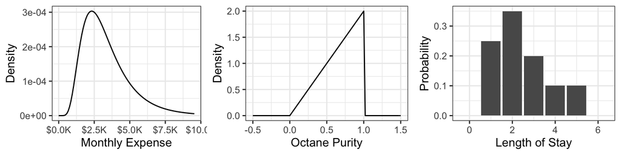

We saw that there are two “versions” of the mean:

- The **empirical mean** is calculated using data, and is an average: $1/n \sum_i X_i$
- The **true mean** is what the empirical mean converges to as we collect more and more data. It can be calculated from a population distribution’s density as $\int_x x f(x) dx.$

Hence, the empirical mean is an *estimate* of the true mean.

**Today**: If the empirical mean is an *estimate* of the true mean, how can we communicate *how good* of an estimate it is? The answer is, by using the distribution of the empirical mean! This distribution has a special name: it’s called a *sampling distribution*.

## Concept 1

**A combination of random variables is also a random variable.**

For example, if $X$, $Y$, and $Z$ are random variables, then…

- $X^Y$ is also a random variable.
- $\exp(X) + Z\sin(Y)$ is also a random variable.
- …

Remember, even though these quantities are made up of many random variables, they still calculate to a single number – hence why they amount to a new single random variable.

In fact, we’ve seen a similar concept in the context of [multi-step simulations](https://ubc-mds.github.io/DSCI_551_stat-prob-dsci/lectures/simulation.html#multi-step-simulations-10-min), where we calculated total “gang demand” from ships arriving at port, and each making a random demand.

## Concept 2

**The empirical mean has a distribution, and is called a *sampling distribution***.

For example, consider the mean of 3 observations of **Length of Stay**. We’ll get different means depending on the sample that’s drawn:

| Ship | Lengths of Stay | Mean |
| --- | --- | --- |
| Ships 1 - 3 | 1, 3, 3 | 2.333 |
| Ships 4 - 6 | 2, 1, 3 | 2 |
| Ships 7 - 9 | 2, 2, 4 | 2.667 |

This is because the underlying sample is random.

To formalize concepts, let’s call three random draws $X_1, X_2, X_3$. Then their mean is
$$\bar{X} = \frac{X_1 + X_2 + X_3}{3},$$
which is a random variable (because each of $X_1, X_2, X_3$ are). This random variable’s distribution is called a *sampling distribution*.

## Demonstration

Let’s use simulation to view the sampling distribution of 10 **Length of Stay** observations.

Steps:

1. Everyone generate their own 10 observations from the **Length of Stay** distribution, and calculate the mean.
   - To start you off, here is code to generate 10 observations:

```
sample(1:5, size = 10, replace = TRUE, prob = c(0.25, 0.35, 0.2, 0.1, 0.1))
```

2. Submit your mean to [this google form](https://docs.google.com/forms/d/e/1FAIpQLSdnQXaFOjKM_Wzsf0O9tMSSjIpXA0Nk34JTUjqtaFP5hy9N0Q/viewform?usp=sf_link).
   - [Spreadsheet of results](https://docs.google.com/spreadsheets/d/1mKuprd-g-IrPekcVuVSkax0_4Kty0NznjFnvAETN32Y/edit#gid=1852227229)

## Other Examples

Here are the sampling distributions of the mean of 10 observations for the three examples we’re considering. They are obtained by generating 1000 means each.

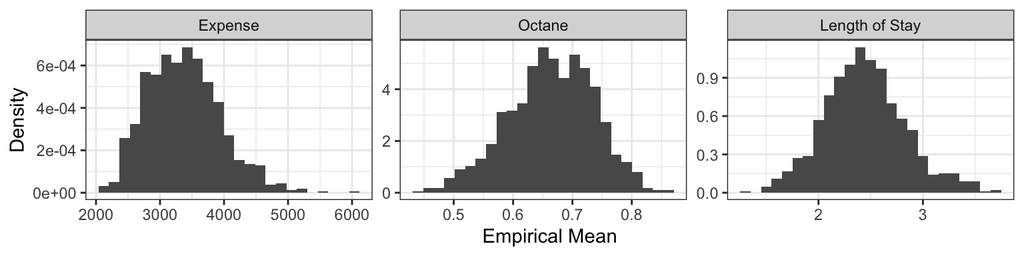